# Tidying, Visualising and Summarising Data - Tasks

Florian Oswald

2025-09-10

## Task 1: Data wrangling

Load the data by running the following code:

```r
library(dslabs)
data(polls_us_election_2016)

library(tidyverse)
```

1. Which polls had a missing `grade`?

Only showing the first 6 rows using `head`, otherwise the document would be very long.

```r
polls_us_election_2016 %>%
    filter(is.na(grade)) %>%
    head
```

```
##          state  startdate    enddate                 pollster grade samplesize
## 1   New Mexico 2016-11-06 2016-11-06                 Zia Poll  <NA>       8439
## 2         U.S. 2016-11-05 2016-11-07 The Times-Picayune/Lucid  <NA>       2521
## 3         U.S. 2016-11-01 2016-11-07    USC Dornsife/LA Times  <NA>       2972
## 4     Virginia 2016-11-01 2016-11-02                Remington  <NA>       3076
## 5    Wisconsin 2016-11-01 2016-11-02                Remington  <NA>       2720
## 6 Pennsylvania 2016-11-01 2016-11-02                Remington  <NA>       2683
##   population rawpoll_clinton rawpoll_trump rawpoll_johnson rawpoll_mcmullin
## 1         lv           46.00         44.00               6               NA
## 2         lv           45.00         40.00               5               NA
## 3         lv           43.61         46.84              NA               NA
## 4         lv           46.00         44.00              NA               NA
## 5         lv           49.00         41.00              NA               NA
## 6         lv           46.00         45.00              NA               NA
##   adjpoll_clinton adjpoll_trump adjpoll_johnson adjpoll_mcmullin
## 1        44.82594      41.59978        7.870127               NA
## 2        45.13966      42.26495        3.679914               NA
## 3        45.32156      43.38579              NA               NA
## 4        45.27399      41.91459              NA               NA
## 5        48.22713      38.86464              NA               NA
## 6        45.30896      42.94988              NA               NA
```

2. Which polls were (i) polled by American Strategies, GfK Group or Merrill Poll, (ii) had a sample size greater than 1,000, *and* (iii) started on October 20th, 2016? (*Hint: for (i) `%in%` might come in handy. Recall that vectors are created using the `c()` function. For (iii) make sure to check the format of the variable containing the poll’s start date.*)

```r
polls_us_election_2016 %>%
    filter(pollster %in% c("American Strategies","GfK Group","Merrill Poll") &
               samplesize > 1000 &
               startdate == "2016-10-20")
```

```
##   state  startdate    enddate  pollster grade samplesize population
## 1  U.S. 2016-10-20 2016-10-24 GfK Group    B+       1212         lv
##   rawpoll_clinton rawpoll_trump rawpoll_johnson rawpoll_mcmullin
## 1              51            37               6               NA
##   adjpoll_clinton adjpoll_trump adjpoll_johnson adjpoll_mcmullin
## 1        50.28058      39.98632        4.733277               NA
```

3. Which polls (i) did not have missing poll data for Johnson, (ii) had a combined raw poll vote share for Trump and Clinton greater than 95% *and* (iii) were done in the state of Ohio? (*Hint: it might be practical to first create a variable containing the combined raw poll vote share for Trump and Clinton and then filter.*)

```r
polls_us_election_2016 %>%
    mutate(rawpoll_clintontrump = rawpoll_clinton + rawpoll_trump) %>%
    filter(!is.na(rawpoll_johnson) & rawpoll_clintontrump > 95 & state == "Ohio")
```

```
##  [1] state                startdate            enddate
##  [4] pollster             grade                samplesize
##  [7] population           rawpoll_clinton      rawpoll_trump
## [10] rawpoll_johnson      rawpoll_mcmullin     adjpoll_clinton
## [13] adjpoll_trump        adjpoll_johnson      adjpoll_mcmullin
## [16] rawpoll_clintontrump
## <0 rows> (or 0-length row.names)
```

4. Which state had the highest average Trump vote share for polls which had at least a sample size of 2,000? (*Hint: you’ll have to use `filter`, `group_by`, `summarise` and `arrange`. To obtain ranking in descending order check `arrange`’s help page.*)

```r
polls_us_election_2016 %>%
    filter(samplesize >= 2000) %>%
    group_by(state) %>%
    summarise(mean_trump = mean(rawpoll_trump)) %>%
    arrange(desc(mean_trump))
```

```
## # A tibble: 26 × 2
##    state          mean_trump
##    <fct>               <dbl>
##  1 Alabama              62.5
##  2 Missouri             48.5
##  3 Indiana              47
##  4 Texas                46.0
##  5 South Carolina       45.5
##  6 Georgia              45.3
##  7 Kansas               44
##  8 New Mexico           44
##  9 Florida              44.0
## 10 Ohio                 43.9
## # ℹ 16 more rows
```

## Task 2: Understanding the data

Load the data by running the following code:

```r
library(dslabs)
data(gapminder, package = "dslabs")
```

1. Compute the average population per continent per year, `mean_pop`, and assign the output to a new object `gapminder_mean`. (*Hint: you should have one observation (row) per continent for each year. You’ll have to use `group_by` and `summarise`.*)

```r
gapminder_mean <- gapminder %>%
  group_by(continent, year) %>%
  summarise(mean_pop = mean(population))
```

## Task 3: Visualising data

Using the `gapminder` data, create the following plots using `ggplot2`. Don’t forget to label the axes.

1. A histogram of life expectancy in 2015. (*Hint: do you need to specify a `y` in `aes()` for a histogram?*) Once you’ve created the histogram, within the appropriate `geom_*` set: `binwidth` to 5, `boundary` to 45, `colour` to “white” and `fill` to “#d90502”. What does each of these options do?  
*Optional:* Using the previous graph, facet it by continent such that each continent’s plot is a new row. (*Hint: check the help for `facet_grid`.*)

The basic histogram:

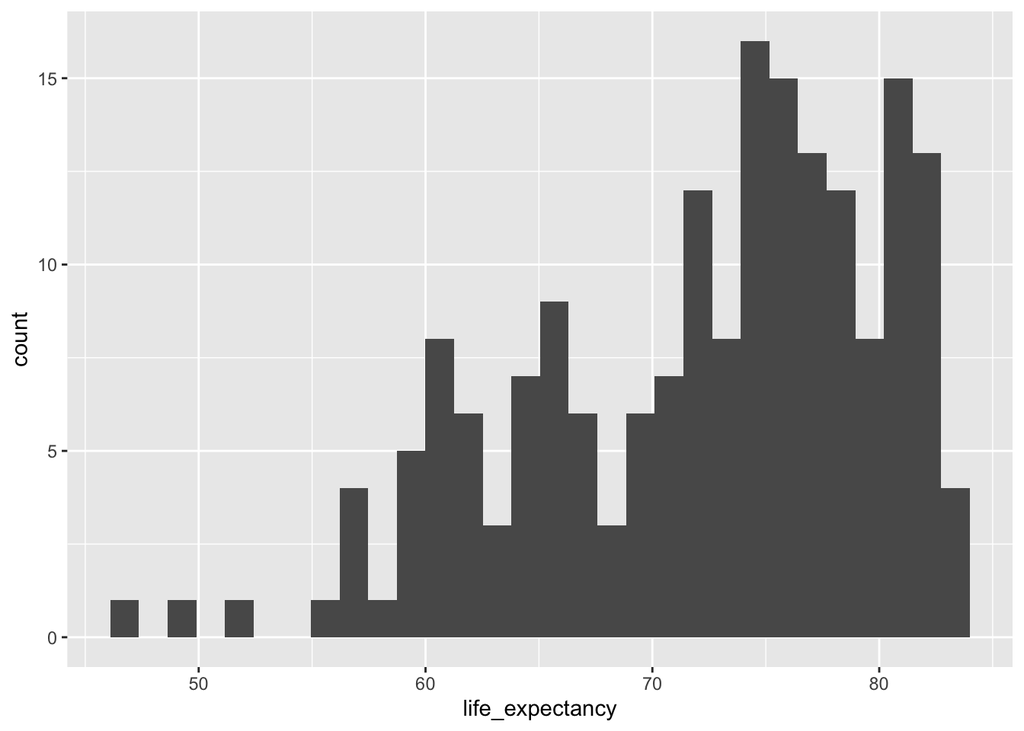

```r
gapminder %>%
    filter(year == 2015) %>%
    ggplot() +
    aes(x = life_expectancy) +
    geom_histogram()
```

The fancy histogram (with axis labels):

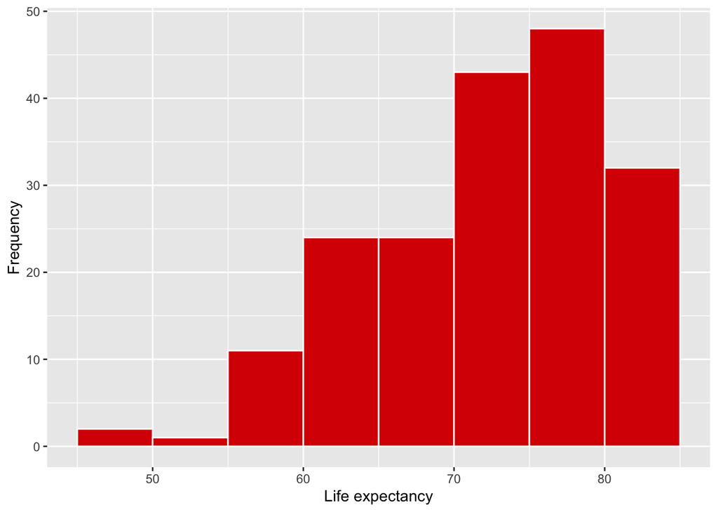

```r
life_exp_hist <- gapminder %>%
    filter(year == 2015) %>%
    ggplot() +
    aes(x = life_expectancy) +
    geom_histogram(binwidth = 5,
                   boundary = 45,
                   colour = "white",
                   fill = "#d90502") +
    labs(x = "Life expectancy",
         y = "Frequency")
life_exp_hist
```

The faceted fancy histogram:

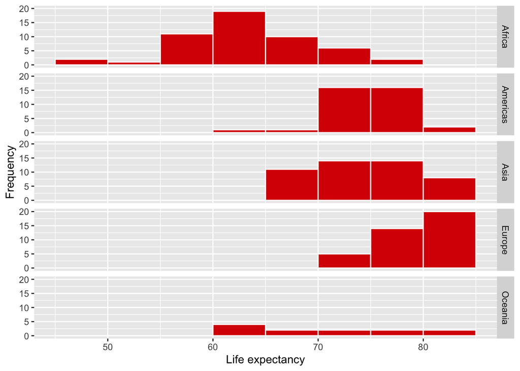

```r
life_exp_hist +
    facet_grid(rows = vars(continent))
```

2. A boxplot of average life expectancy per year by continent. Within the appropriate `geom_*` set: `colour` to “black” and `fill` to “#d90502”. (*Hint: you need to group by both `continent` and `year`.*)

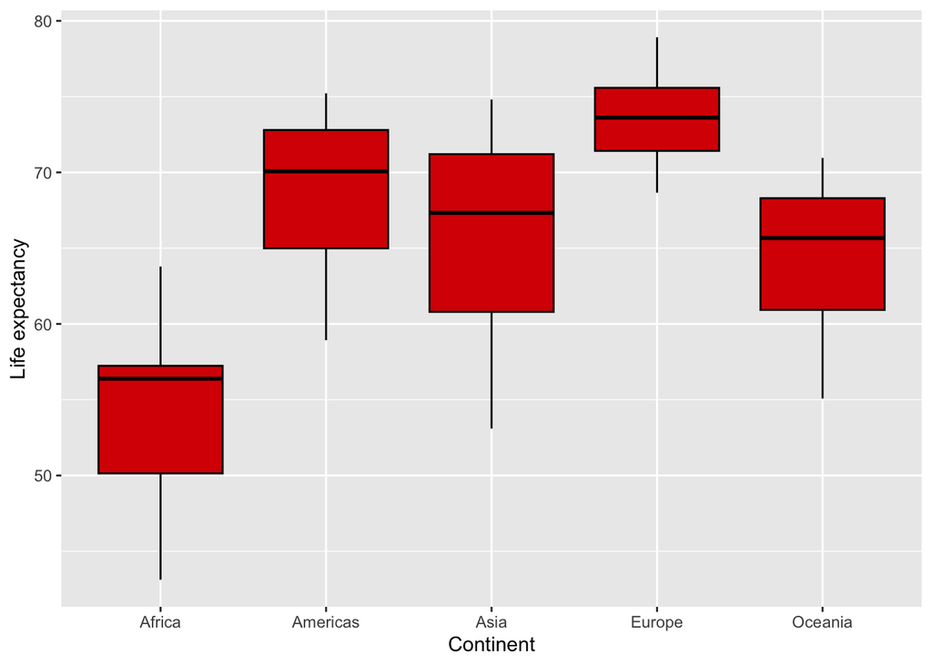

```r
gapminder %>%
    group_by(continent, year) %>%
    summarise(mean_life_exp = mean(life_expectancy)) %>%
    ggplot() +
    aes(x = continent, y = mean_life_exp) +
    geom_boxplot(colour = "black",
                 fill = "#d90502") +
    labs(x = "Continent",
         y = "Life expectancy")
```

3. A scatter plot of fertility rate (y-axis) with respect to infant mortality (x-axis) in 2015. Once you’ve created the scatter plot, within the appropriate `geom_*` set: `size` to 3, `alpha` to 0.5, `colour` to “#d90502”.

The basic scatter plot:

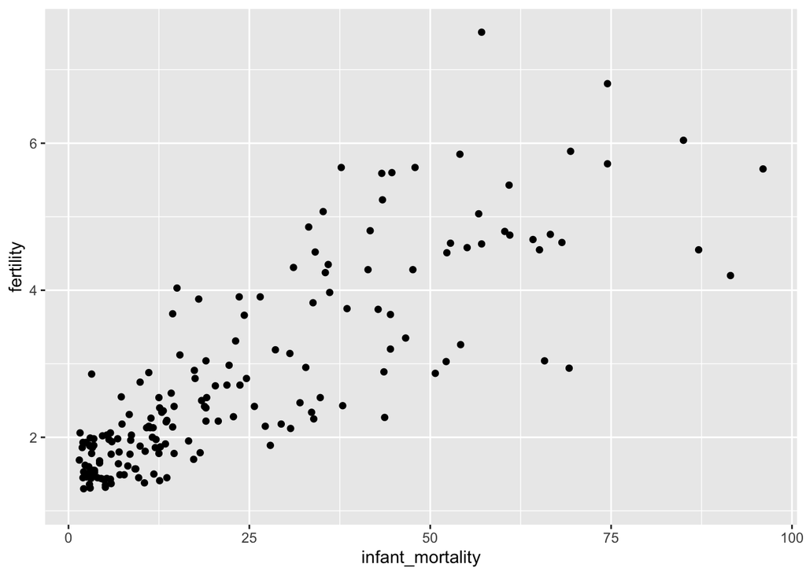

```r
gapminder %>%
    filter(year == 2015) %>%
    ggplot() +
    aes(x = infant_mortality, y = fertility) +
    geom_point()
```

The fancy scatter plot with axis labels:

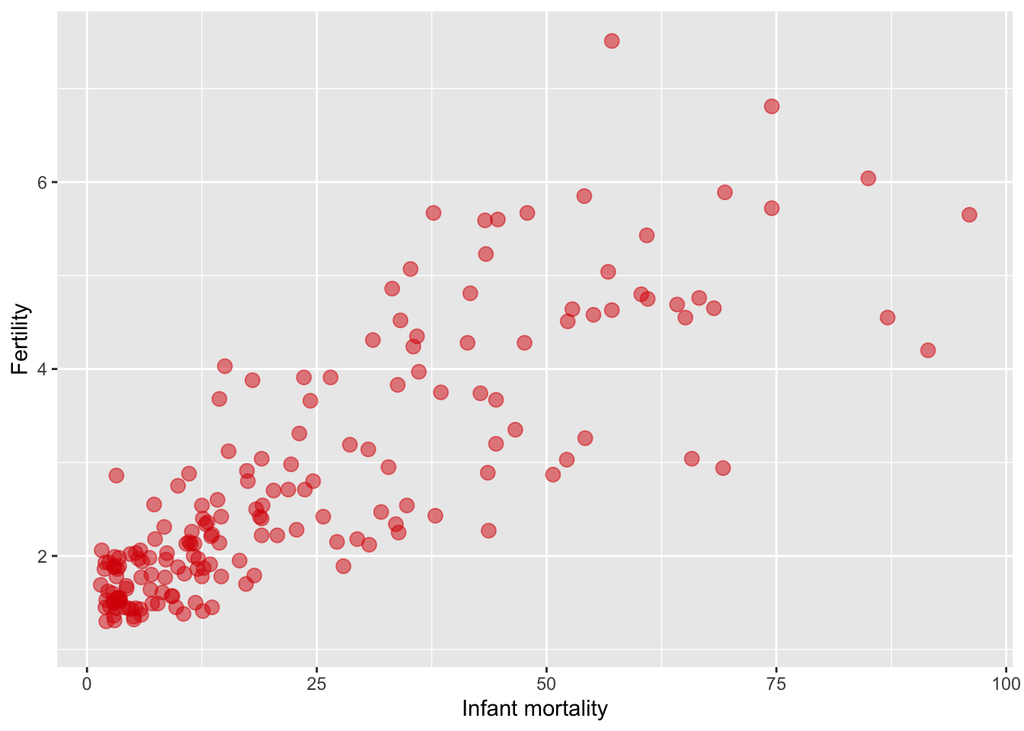

```r
gapminder %>%
    filter(year == 2015) %>%
    ggplot() +
    aes(x = infant_mortality, y = fertility) +
    geom_point(size = 3,
               alpha = 0.5,
               colour = "#d90502") +
    labs(x = "Infant mortality", y = "Fertility")
```

## Task 4: Summarising data

1. Compute the mean of GDP in 2011 and assign to object `mean`. You should exclude missing values. (*Hint: read the help for `mean` to remove `NA`s*).

```r
mean <- gapminder %>%
    filter(year == 2011) %>%
    summarise(mean(gdp, na.rm = T))
mean
```

```
##   mean(gdp, na.rm = T)
## 1         246954895975
```

2. Compute the median of GDP in 2011 and assign to object `median`. Again, you should exclude missing values. Is it greater or smaller than the average?

```r
median <- gapminder %>%
    filter(year == 2011) %>%
    summarise(median(gdp, na.rm = T))
median
```

```
##   median(gdp, na.rm = T)
## 1            16031265698
```

**The median is much smaller than the average.**

3. Create a density plot of GDP in 2011 using `geom_density`. A density plot is a way of representing the distribution of a numeric variable. Add the following code to your plot to show the median and mean as vertical lines. What do you observe? `geom_vline(xintercept = as.numeric(mean), colour = "red") + <br> geom_vline(xintercept = as.numeric(median), colour = "orange")`

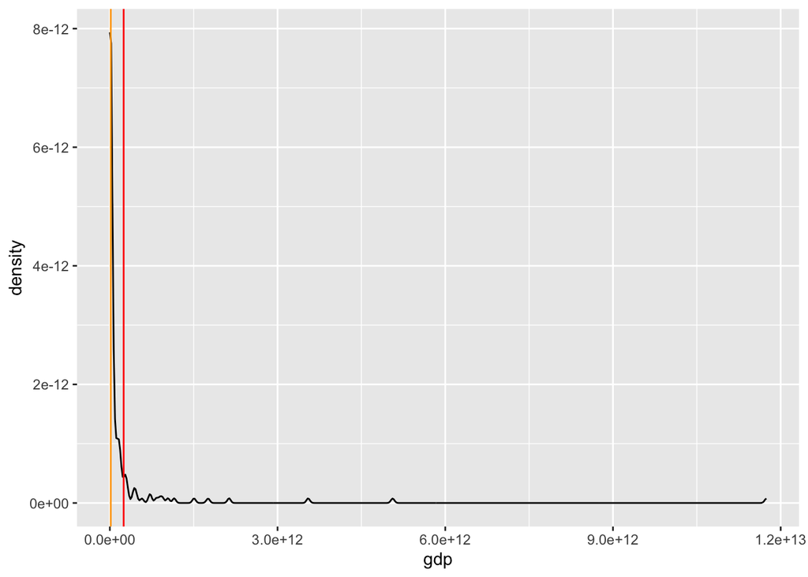

```r
gdp_density <- gapminder %>%
    filter(year == 2011) %>%
    ggplot() +
    aes(x = gdp) +
    geom_density() +
    geom_vline(xintercept = as.numeric(mean), colour = "red") +
    geom_vline(xintercept = as.numeric(median), colour = "orange")
gdp_density
```

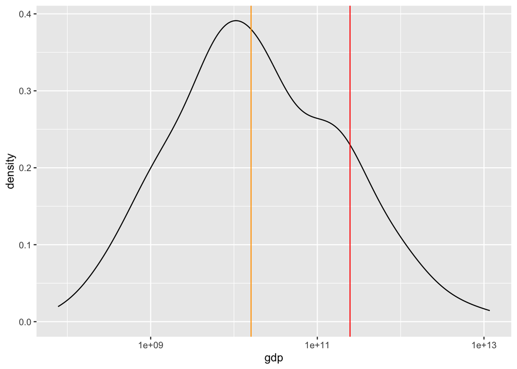

```r
gdp_density +
    scale_x_log10()
```

4. Compute the correlation between fertility and infant mortality in 2015. To drop `NA`s in either variable set the argument `use` to “pairwise.complete.obs” in your `cor()` function. Is this correlation consistent with the graph you produced in Task 3?

```r
gapminder %>%
    filter(year == 2015) %>%
    summarise(cor(fertility, infant_mortality, use = "pairwise.complete.obs"))
```

```
##   cor(fertility, infant_mortality, use = "pairwise.complete.obs")
## 1                                                       0.8286402
```

**This correlation is positive and strong (relatively close to 1) which is consistent with the graph produced in Task 3. Indeed, that graph displayed a positive relationship between these two variables and the points were not that dispersed.**